# Regresión Lineal desde Cero

Ejercicio Práctico — Estadística II, CIDE

Benjamín Oliva

25 de mayo de 2026

# 1 Objetivo

En este ejercicio construiremos **paso a paso** el estimador de Mínimos Cuadrados Ordinarios (MCO) para un modelo de regresión lineal múltiple, siguiendo la notación y el desarrollo de las notas de clase. Vamos a:

1. Generar datos sintéticos a partir de un modelo conocido.
2. Construir las matrices $\mathbf{X}$ y el vector $\mathbf{Y}$.
3. Calcular $\hat{\boldsymbol{\beta}} = (\mathbf{X}'\mathbf{X})^{-1}\mathbf{X}'\mathbf{Y}$ a mano.
4. Obtener residuales, $\hat{\sigma}^2$ y errores estándar.
5. Realizar pruebas de hipótesis individuales ($t$) y global ($F$).
6. Calcular e interpretar el $R^2$.
7. Verificar todo con `lm()`.

```r
library(tidyverse)
library(knitr)
library(kableExtra)
```

# 2 Modelo y datos sintéticos

## 2.1 El modelo verdadero

Supongamos que queremos explicar el salario mensual (en miles de pesos) de un trabajador en función de sus años de educación y sus años de experiencia. El modelo poblacional es:

$$Y_i = \beta_0 + \beta_1 \text{Educ}_i +
\beta_2 \text{Exper}_i + \varepsilon_i$$

donde $\varepsilon_i \sim N(0, \sigma^2)$, con los siguientes parámetros verdaderos:

$$\beta_0 = 5, \quad \beta_1 = 2.5, \quad
\beta_2 = 1.2, \quad \sigma = 3$$

Es decir, cada año adicional de educación se asocia con un incremento de 2.5 mil pesos, y cada año de experiencia con un incremento de 1.2 mil pesos.

## 2.2 Generación de los datos

```r
set.seed(42) # Fijamos semilla para reproducibilidad

n <- 50 # Tamaño de muestra

# Parámetros verdaderos
beta_true <- c(5, 2.5, 1.2)
sigma_true <- 3

# Variables independientes
educ  <- round(runif(n, min = 6, max = 22), 1)   # Años de educación
exper <- round(runif(n, min = 0, max = 30), 1)    # Años de experiencia

# Error aleatorio
epsilon <- rnorm(n, mean = 0, sd = sigma_true)

# Variable dependiente
salario <- beta_true[1] + beta_true[2] * educ + beta_true[3] * exper + epsilon

# Data frame
datos <- data.frame(salario, educ, exper)

head(datos, 10)
```

|  | salario | educ | exper |
| --- | --- | --- | --- |
| 1 | 69.46578 | 20.6 | 10.0 |
| 2 | 67.62848 | 21.0 | 10.4 |
| 3 | 50.62718 | 10.6 | 12.0 |
| 4 | 83.37870 | 19.3 | 23.5 |
| 5 | 47.45928 | 16.3 | 1.2 |
| 6 | 68.57965 | 14.3 | 22.5 |
| 7 | 75.89787 | 17.8 | 20.3 |
| 8 | 31.88950 | 8.2 | 5.1 |
| 9 | 46.63073 | 16.5 | 7.8 |
| 10 | 67.58465 | 17.3 | 15.4 |

## 2.3 Estadísticas descriptivas

```r
summary(datos)
```

```
##     salario           educ           exper
##  Min.   :28.00   Min.   : 6.10   Min.   : 0.00
##  1st Qu.:50.31   1st Qu.:12.38   1st Qu.: 6.35
##  Median :63.77   Median :16.25   Median :13.20
##  Mean   :60.47   Mean   :15.58   Mean   :13.50
##  3rd Qu.:69.85   3rd Qu.:20.43   3rd Qu.:20.68
##  Max.   :96.77   Max.   :21.80   Max.   :29.50
```

## 2.4 Visualización exploratoria

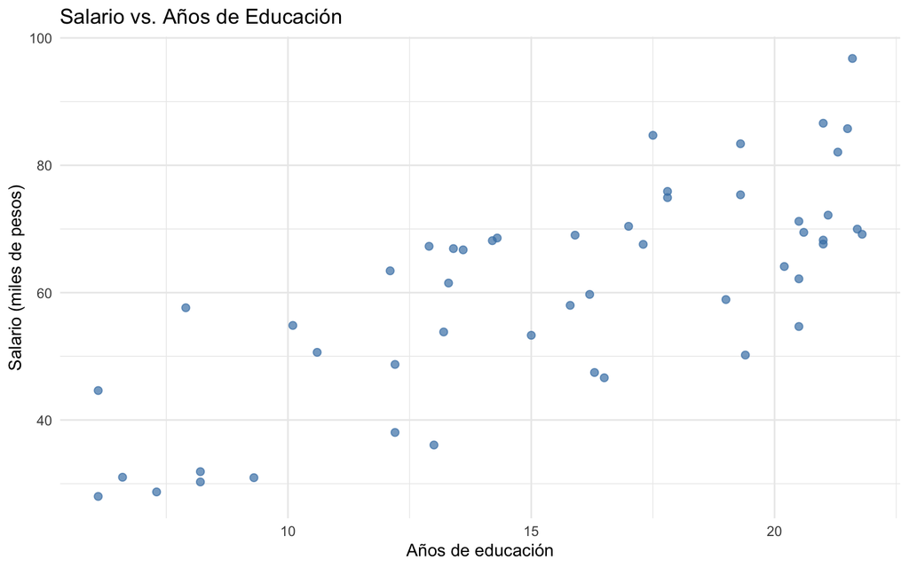

```r
ggplot(datos, aes(x = educ, y = salario)) +
  geom_point(color = "steelblue", size = 2, alpha = 0.7) +
  labs(title = "Salario vs. Años de Educación",
       x = "Años de educación", y = "Salario (miles de pesos)") +
  theme_minimal()
```

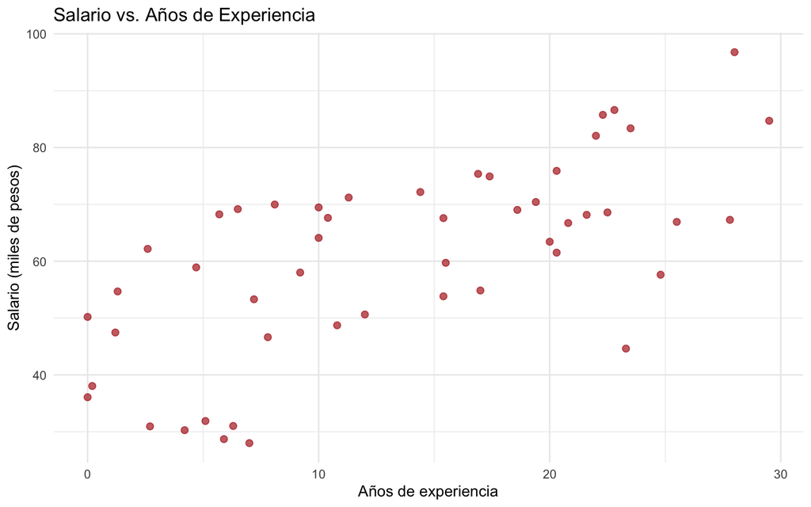

```r
ggplot(datos, aes(x = exper, y = salario)) +
  geom_point(color = "firebrick", size = 2, alpha = 0.7) +
  labs(title = "Salario vs. Años de Experiencia",
       x = "Años de experiencia", y = "Salario (miles de pesos)") +
  theme_minimal()
```

# 3 Construcción matricial del estimador MCO

## 3.1 Definición de $\mathbf{X}$ y $\mathbf{Y}$

Recordemos de las notas que definimos:

$$\mathbf{Y} = \begin{pmatrix} y_1 \\ y_2
\\ \vdots \\ y_n \end{pmatrix}, \qquad \mathbf{X} = \begin{pmatrix} 1
& x_{11} & x_{12} \\ 1 & x_{21} & x_{22} \\ \vdots &
\vdots & \vdots \\ 1 & x_{n1} & x_{n2}
\end{pmatrix}$$

donde la primera columna de $\mathbf{X}$ es un vector de unos (la constante).

```r
# Vector Y
Y <- matrix(salario, ncol = 1)

# Matriz X (con columna de unos)
X <- cbind(1, educ, exper)

cat("Dimensiones de X:", dim(X), "\n")
```

```
## Dimensiones de X: 50 3
```

```r
cat("Dimensiones de Y:", dim(Y), "\n")
```

```
## Dimensiones de Y: 50 1
```

Verifiquemos las primeras filas:

```r
head(X)
```

```
##        educ exper
## [1,] 1 20.6  10.0
## [2,] 1 21.0  10.4
## [3,] 1 10.6  12.0
## [4,] 1 19.3  23.5
## [5,] 1 16.3   1.2
## [6,] 1 14.3  22.5
```

```r
head(Y)
```

```
##          [,1]
## [1,] 69.46578
## [2,] 67.62848
## [3,] 50.62718
## [4,] 83.37870
## [5,] 47.45928
## [6,] 68.57965
```

## 3.2 Cálculo de $\mathbf{X}'\mathbf{X}$

De las notas:

$$\mathbf{X}'\mathbf{X} =
\begin{pmatrix} n & \sum x_{i1} & \sum x_{i2} \\ \sum x_{i1}
& \sum x_{i1}^2 & \sum x_{i1}x_{i2} \\ \sum x_{i2} & \sum
x_{i2}x_{i1} & \sum x_{i2}^2 \end{pmatrix}$$

```r
XtX <- t(X) %*% X
XtX
```

```
##                 educ    exper
##        50.0   779.20   675.20
## educ  779.2 13298.68 10638.48
## exper 675.2 10638.48 12680.52
```

Notemos que $\mathbf{X}'\mathbf{X}$ es simétrica, como lo señalan las notas:

```r
# Verificamos simetría
all.equal(XtX, t(XtX))
```

```
## [1] TRUE
```

## 3.3 Cálculo de $\mathbf{X}'\mathbf{Y}$

$$\mathbf{X}'\mathbf{Y} =
\begin{pmatrix} \sum y_i \\ \sum x_{i1} y_i \\ \sum x_{i2} y_i
\end{pmatrix}$$

```r
XtY <- t(X) %*% Y
XtY
```

```
##            [,1]
##        3023.345
## educ  50143.212
## exper 45533.402
```

## 3.4 El estimador $\hat{\boldsymbol{\beta}} = (\mathbf{X}'\mathbf{X})^{-1}\mathbf{X}'\mathbf{Y}$

```r
XtX_inv <- solve(XtX)  # Inversa de X'X
beta_hat <- XtX_inv %*% XtY

cat("Estimadores:\n")
```

```
## Estimadores:
```

```r
cat("  β̂₀ (intercepto) =", round(beta_hat[1], 4), "\n")
```

```
##   β̂₀ (intercepto) = 4.8434
```

```r
cat("  β̂₁ (educación)  =", round(beta_hat[2], 4), "\n")
```

```
##   β̂₁ (educación)  = 2.4951
```

```r
cat("  β̂₂ (experiencia)=", round(beta_hat[3], 4), "\n")
```

```
##   β̂₂ (experiencia)= 1.2396
```

```r
cat("\nParámetros verdaderos: β₀ =", beta_true[1],
    ", β₁ =", beta_true[2], ", β₂ =", beta_true[3], "\n")
```

```
##
## Parámetros verdaderos: β₀ = 5 , β₁ = 2.5 , β₂ = 1.2
```

# 4 Residuales y estimación de $\sigma^2$

## 4.1 Vector de residuales

$$\mathbf{e} = \mathbf{Y} -
\mathbf{X}\hat{\boldsymbol{\beta}}$$

```r
Y_hat <- X %*% beta_hat     # Valores ajustados
e     <- Y - Y_hat           # Residuales

cat("Suma de residuales (debe ser ≈ 0):", round(sum(e), 10), "\n")
```

```
## Suma de residuales (debe ser ≈ 0): 0
```

## 4.2 Estimador insesgado de $\sigma^2$

De las notas:

$$\hat{\sigma}^2 =
\frac{\mathbf{e}'\mathbf{e}}{n - (K+1)}$$

donde $K+1$ es el número de parámetros (en nuestro caso, $K+1 = 3$).

```r
K_plus_1 <- ncol(X)  # Número de parámetros
gl <- n - K_plus_1   # Grados de libertad

sigma2_hat <- as.numeric(t(e) %*% e) / gl

cat("σ̂² =", round(sigma2_hat, 4), "\n")
```

```
## σ̂² = 7.9094
```

```r
cat("σ̂  =", round(sqrt(sigma2_hat), 4), "\n")
```

```
## σ̂  = 2.8124
```

```r
cat("σ verdadero =", sigma_true, "\n")
```

```
## σ verdadero = 3
```

## 4.3 Distribución muestral de $\hat{\boldsymbol{\beta}}$

De las notas:

$$\hat{\boldsymbol{\beta}} \sim
N\left(\boldsymbol{\beta},\; \hat{\sigma}^2
(\mathbf{X}'\mathbf{X})^{-1}\right)$$

```r
Var_beta <- sigma2_hat * XtX_inv

cat("Matriz de varianzas-covarianzas de β̂:\n")
```

```
## Matriz de varianzas-covarianzas de β̂:
```

```r
round(Var_beta, 6)
```

```
##                      educ     exper
##        2.137796 -0.103988 -0.026590
## educ  -0.103988  0.006867 -0.000224
## exper -0.026590 -0.000224  0.002227
```

Los errores estándar de cada coeficiente son la raíz de la diagonal:

```r
se_beta <- sqrt(diag(Var_beta))

cat("Errores estándar:\n")
```

```
## Errores estándar:
```

```r
cat("  SE(β̂₀) =", round(se_beta[1], 4), "\n")
```

```
##   SE(β̂₀) = 1.4621
```

```r
cat("  SE(β̂₁) =", round(se_beta[2], 4), "\n")
```

```
##   SE(β̂₁) = 0.0829
```

```r
cat("  SE(β̂₂) =", round(se_beta[3], 4), "\n")
```

```
##   SE(β̂₂) = 0.0472
```